# IODS course project

Valeria Peshko

# Introduction to Open Data Science - Course Project

# About the project

## How am I feeling right now?

- Overwhelmed
- Excited
- Slightly confused

It feels as if you gave us written instructions to teach us how to swim, and now I am in the water, trying to understand these instructions and not to drown.

## What do I expect to learn?

I would like to learn the how to perform statistical analysis with R.

## Where did I hear about the course?

I’ve found the course when I was looking for options to learn data science in *University of Helsinki*.

## My GitHub Repository

[Click here!](https://github.com/vapeshko/IODS-project)

# Approaches to learning: a data analysis

## Aim of the chapter and data

This chapter explores the impact of various factors on learning outcomes. To achieve this aim a survey was conducted among statistics course students in 2014. The researchers collected information about gender and age of the participants. The survey asked the participants to indicate their attitude towards statistics, and fill in the questionnaire describing their learning habits. The answers were divided into three categories, describing general ways of learning. They were defined as deep, surface and strategic learning. Finally, the final mark of the course, given in points, was included in the data. After initial processing of the data, I have produced a data set, consisting of 166 observations over 7 variables.

```r
learning2014 <- read.table("Z:\\Documents\\RProjects\\IODS-project\\data\\learning2014.csv", header = TRUE, sep = ",", row.names = 1)

dim(learning2014)
```

```
## [1] 166   7
```

```r
str(learning2014)
```

```
## 'data.frame':    166 obs. of  7 variables:
##  $ gender  : chr  "F" "M" "F" "M" ...
##  $ age     : int  53 55 49 53 49 38 50 37 37 42 ...
##  $ attitude: int  37 31 25 35 37 38 35 29 38 21 ...
##  $ points  : int  25 12 24 10 22 21 21 31 24 26 ...
##  $ deep    : num  3.44 2.89 3.44 3.33 3.44 ...
##  $ surf    : num  2.58 3.17 2.25 2.25 2.83 ...
##  $ stra    : num  3.38 2.75 3.62 3.12 3.62 ...
```

## Summary statistics

In our further analysis we plan to investigate the impact on learning outcomes, that is, we are treating our *points* variable as dependent variable. Our analysis of the correlation between different variables indicates that *attitude* has the strongest and most statistically significant relationship to *points*. Less significant, but still of interest, is potential positive association of the course mark with strategic learning (*stra*) and negative one with surface learning (*surf*). These relationships make common sense: positive attitude towards the study subject and strategic approach to learning result in higher marks, while surface learning allows very limited understanding of the subject and will probably lead to a lower grade. In the next section we will introduce some tests to these assumptions.

```r
#changing the order of rows
library(dplyr)
```

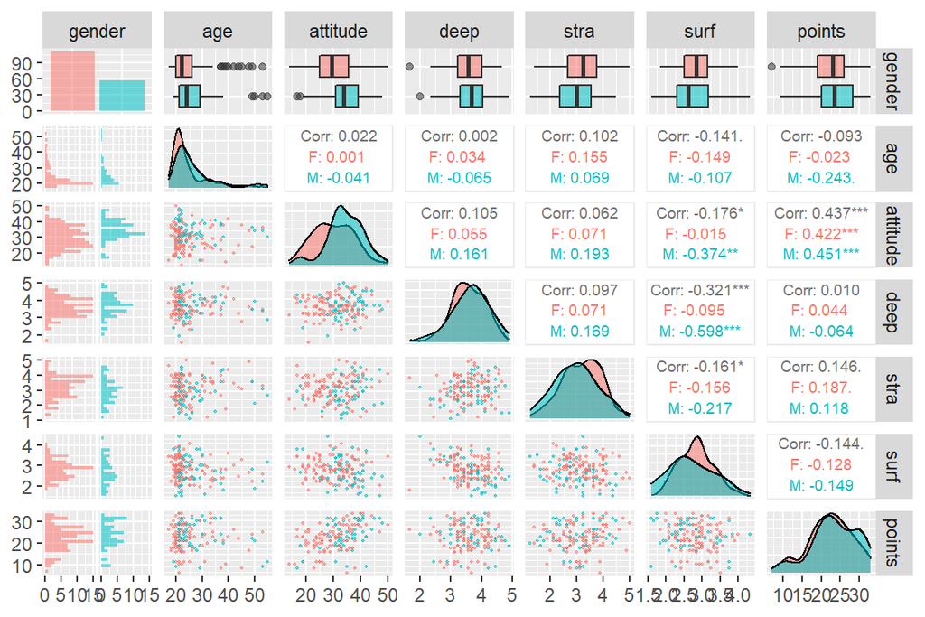

```r
learning2014 <- select(learning2014, one_of(c("gender","age","attitude","deep", "stra", "surf", "points")))

library(ggplot2)
library(GGally)
ggpairs(learning2014, mapping = aes(col=gender, alpha = 0.3), upper = list(continuous = wrap("cor", size=2.5)), lower = list(continuous = wrap("points", size = 0.3), combo = wrap("facethist", bins = 20)))
```

## Linear regression analysis and model validation

Our first attempt at fitting the linear model has demonstrated that only attitude has a statistically significant association with the grade of the course. Although beta coefficients of strategic and surface learning are higher, their low t-values and high p-values, do not allow us to interpret them as significant enough. As the R<sup>2</sup> value suggests,the current model explains around 19% of our records.

```r
model_learning2014 <- lm(points~ attitude + stra + surf, data = learning2014)

summary(model_learning2014)
```

```
##
## Call:
## lm(formula = points ~ attitude + stra + surf, data = learning2014)
##
## Residuals:
##      Min       1Q   Median       3Q      Max
## -17.1550  -3.4346   0.5156   3.6401  10.8952
##
## Coefficients:
##             Estimate Std. Error t value Pr(>|t|)
## (Intercept) 11.01711    3.68375   2.991  0.00322 **
## attitude     0.33952    0.05741   5.913 1.93e-08 ***
## stra         0.85313    0.54159   1.575  0.11716
## surf        -0.58607    0.80138  -0.731  0.46563
## ---
## Signif. codes:  0 '***' 0.001 '**' 0.01 '*' 0.05 '.' 0.1 ' ' 1
##
## Residual standard error: 5.296 on 162 degrees of freedom
## Multiple R-squared:  0.2074, Adjusted R-squared:  0.1927
## F-statistic: 14.13 on 3 and 162 DF,  p-value: 3.156e-08
```

For the next step we have excluded surface learning from the equation. Overall, it did not significantly change our initial results. It shows very similar results for our *attitude* variable, and the statistical significance of strategic learning has increased only to the 0.1 level.

**We can conclude that attitude towards statistics and strategic learning to some extent are positively associated with the final grade.** In other words, positive attitude towards the study subject and strategizing the learning process increase chances to complete the course successfully.

```r
model2_learning2014 <- lm(points~ attitude + stra, data = learning2014)
summary(model2_learning2014)
```

```
##
## Call:
## lm(formula = points ~ attitude + stra, data = learning2014)
##
## Residuals:
##      Min       1Q   Median       3Q      Max
## -17.6436  -3.3113   0.5575   3.7928  10.9295
##
## Coefficients:
##             Estimate Std. Error t value Pr(>|t|)
## (Intercept)  8.97290    2.39591   3.745  0.00025 ***
## attitude     0.34658    0.05652   6.132 6.31e-09 ***
## stra         0.91365    0.53447   1.709  0.08927 .
## ---
## Signif. codes:  0 '***' 0.001 '**' 0.01 '*' 0.05 '.' 0.1 ' ' 1
##
## Residual standard error: 5.289 on 163 degrees of freedom
## Multiple R-squared:  0.2048, Adjusted R-squared:  0.1951
## F-statistic: 20.99 on 2 and 163 DF,  p-value: 7.734e-09
```

To make sure that the second model is the best one, we are going to compare their AIC values. Indeed, we can observe that the model with only two variables *attitude* and strategic learning (*stra*) has the lowest AIC index, so it is a better fit.

```r
library(AICcmodavg)

models <- list(model_learning2014, model2_learning2014)
mod.names <- c("att.stra.surf", "att.stra")
aictab(cand.set = models, modnames = mod.names)
```

```
##
## Model selection based on AICc:
##
##               K    AICc Delta_AICc AICcWt Cum.Wt      LL
## att.stra      4 1029.29       0.00   0.69   0.69 -510.52
## att.stra.surf 5 1030.87       1.58   0.31   1.00 -510.25
```

Finally, we are going to test the validity of our model. Our constant variance assumption is tested with residuals vs fitted values plot. Since we can observe no questionable patterns, we can conclude that the assumption is valid. We test normality assumption with a QQ-plot, which suggests that the errors are reasonably distributed. Our Residuals vs Leverage plot shows that no value has a significant leverage. As you can see the scale of the leverage axis, the highest value is estimated to be only around 0.05.

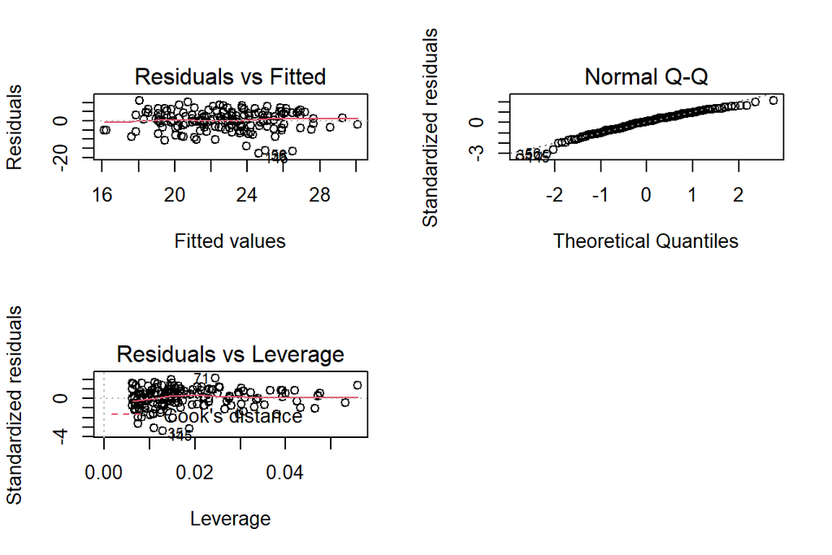

```r
par(mfrow = c(2,2))
plot(model2_learning2014, which=c(1,2,5))
```

# Alchohol consumption among teenagers

## Aim of the chapter and data

This chapter investigates factors connected to high consumption of alcohol among teenagers. I am going to use the data from two surveys, collected by Prof Paulo Cortez (see more infromation about the data [here](https://archive.ics.uci.edu/ml/datasets/Student+Performance)). The data set consists of 370 observations and 35 variables.

```r
date()
```

```
## [1] "Fri Dec 10 17:27:16 2021"
```

```r
library(dplyr)
alc <- read.csv(file = "Z:\\Documents\\RProjects\\IODS-project\\data\\students.csv")

glimpse(alc)
```

```
## Rows: 370
## Columns: 36
## $ X          <int> 1, 2, 3, 4, 5, 6, 7, 8, 9, 10, 11, 12, 13, 14, 15, 16, 17, ~
## $ school     <chr> "GP", "GP", "GP", "GP", "GP", "GP", "GP", "GP", "GP", "GP",~
## $ sex        <chr> "F", "F", "F", "F", "F", "M", "M", "F", "M", "M", "F", "F",~
## $ age        <int> 18, 17, 15, 15, 16, 16, 16, 17, 15, 15, 15, 15, 15, 15, 15,~
## $ address    <chr> "U", "U", "U", "U", "U", "U", "U", "U", "U", "U", "U", "U",~
## $ famsize    <chr> "GT3", "GT3", "LE3", "GT3", "GT3", "LE3", "LE3", "GT3", "LE~
## $ Pstatus    <chr> "A", "T", "T", "T", "T", "T", "T", "A", "A", "T", "T", "T",~
## $ Medu       <int> 4, 1, 1, 4, 3, 4, 2, 4, 3, 3, 4, 2, 4, 4, 2, 4, 4, 3, 3, 4,~
## $ Fedu       <int> 4, 1, 1, 2, 3, 3, 2, 4, 2, 4, 4, 1, 4, 3, 2, 4, 4, 3, 2, 3,~
## $ Mjob       <chr> "at_home", "at_home", "at_home", "health", "other", "servic~
## $ Fjob       <chr> "teacher", "other", "other", "services", "other", "other", ~
## $ reason     <chr> "course", "course", "other", "home", "home", "reputation", ~
## $ guardian   <chr> "mother", "father", "mother", "mother", "father", "mother",~
```

[output cut: 23 more lines]

## Selecting possible factors and formulating a hypothesis

My first assumption is that high consumption of alcohol(`high_use`) would be visible in teens’ school performance, i.e. in grades (`G3`) and class `failures`, as well as their `absences` from school. I also speculate that difficult relationship with family may lead to alcohol abuse (`famrel`, evaluated by respondents on the scale from 0 to 5). Moreover, I assume that teenagers from urban districts might consume much more alcohol than their counterparts from rural areas, due to easier access to bars, clubs and parties (`address`). Finally, I will consider the impact of gender (coded here as `sex`).

```r
library(tidyr)

alc$address <- alc$address %>% as.factor()
alc$sex <- alc$sex %>% as.factor()

alc %>% group_by(address, high_use) %>%  summarise(count = n(), mean_grade = mean(G3), failures = mean(failures), absences = mean(absences), famrel = mean(famrel))
```

```
## # A tibble: 4 x 7
## # Groups:   address [2]
##   address high_use count mean_grade failures absences famrel
##   <fct>   <lgl>    <int>      <dbl>    <dbl>    <dbl>  <dbl>
## 1 R       FALSE       50       10.4    0.12      4.44   4.02
## 2 R       TRUE        31       10.7    0.452     5.61   3.71
## 3 U       FALSE      209       12.1    0.120     3.54   4.00
## 4 U       TRUE        80       10.9    0.312     6.68   3.79
```

```r
alc %>% group_by(sex, high_use) %>%  summarise(count = n(), mean_grade = mean(G3), failures = mean(failures), absences = mean(absences), famrel = mean(famrel))
```

```
## # A tibble: 4 x 7
## # Groups:   sex [2]
##   sex   high_use count mean_grade failures absences famrel
##   <fct> <lgl>    <int>      <dbl>    <dbl>    <dbl>  <dbl>
## 1 F     FALSE      154       11.4    0.104     4.25   3.92
## 2 F     TRUE        41       11.8    0.293     6.85   3.73
## 3 M     FALSE      105       12.3    0.143     2.91   4.13
## 4 M     TRUE        70       10.3    0.386     6.1    3.79
```

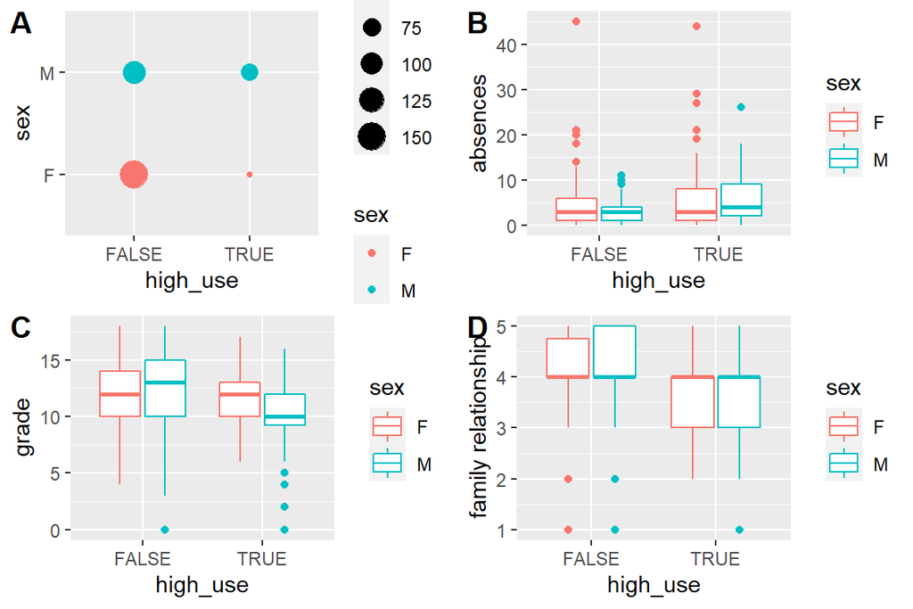

```r
library(ggplot2)
library(cowplot)

g1 <- ggplot(alc, aes(x = high_use, y =sex, col= sex)) + geom_count()

g2 <- ggplot(alc, aes(x = high_use, y = absences, col=sex)) + geom_boxplot()

g4 <- ggplot(alc, aes(x = high_use, y = G3, col=sex)) + geom_boxplot() + ylab("grade")

g5 <- ggplot(alc, aes(x = high_use, y = famrel, col = sex)) + geom_boxplot()+ ylab("family relationship")

plot_grid(g1, g2, g4, g5, labels = "AUTO")
```

## The Model

To get a model, that could detect teenagers with high values of alcohol use I am going to create four logistic models with different combinations of variables, I discussed above, as predictors. Then, I am going to test, which model has the lowest AIC value, i.e. is a better fitting one. The table below shows that the best model (`m2`) includes `failures`, `absences`, `sex` and `famrel`.

Next, I am calculating odds ratios from regression coefficients. The resulting values should be interpreted as follows:

- for a one unit increase in `failures` the odds of having `high_use` as TRUE increase by 77%.
- for a one unit increase in `absences` the odds of having `high_use` as TRUE increase by 9%.
- for boys the the odds of having `high_use` as TRUE increase by 185%.
- for a one unit increase in `famrel` the odds of having `high_use` as TRUE decrease by 26%.

None of the confidence intervals contain 1, which means that all variables are not independent from `high_use`.

```r
m1 <- glm(high_use ~ failures + absences + sex + G3 + famrel, data = alc, family = "binomial")

m2 <- glm(high_use ~ failures + absences + sex + famrel, data = alc, family = "binomial")

m3 <- glm(high_use ~ failures + absences + sex, data = alc, family = "binomial")

m4 <- glm(high_use ~ famrel + absences + sex, data = alc, family = "binomial")

library(AICcmodavg)

models <- list(m1, m2, m3, m4)
mod.names <- c("fal.abs.sex.gr.fam", "fal.abs.sex.fam","fal.abs.sex", "abs.sex.fam" )
aictab(cand.set = models, modnames = mod.names)
```

```
##
## Model selection based on AICc:
##
##                    K   AICc Delta_AICc AICcWt Cum.Wt      LL
## fal.abs.sex.fam    5 411.94       0.00   0.52   0.52 -200.89
## fal.abs.sex.gr.fam 6 412.72       0.78   0.35   0.87 -200.24
## fal.abs.sex        4 415.10       3.17   0.11   0.97 -203.50
## abs.sex.fam        4 417.94       6.00   0.03   1.00 -204.92
```

```r
summary(m2)
```

```
##
## Call:
## glm(formula = high_use ~ failures + absences + sex + famrel,
##     family = "binomial", data = alc)
##
## Deviance Residuals:
##     Min       1Q   Median       3Q      Max
## -2.0786  -0.8216  -0.5746   0.9760   2.1820
##
## Coefficients:
##             Estimate Std. Error z value Pr(>|z|)
## (Intercept) -0.79406    0.54281  -1.463  0.14350
## failures     0.57328    0.20531   2.792  0.00523 **
## absences     0.08941    0.02274   3.932 8.43e-05 ***
## sexM         1.04800    0.25091   4.177 2.96e-05 ***
## famrel      -0.29791    0.13044  -2.284  0.02238 *
## ---
## Signif. codes:  0 '***' 0.001 '**' 0.01 '*' 0.05 '.' 0.1 ' ' 1
##
## (Dispersion parameter for binomial family taken to be 1)
##
##     Null deviance: 452.04  on 369  degrees of freedom
## Residual deviance: 401.77  on 365  degrees of freedom
## AIC: 411.77
##
## Number of Fisher Scoring iterations: 4
```

```r
OR <- coef(m2) %>% exp
CI <- confint(m2) %>% exp
cbind(OR, CI)
```

```
##                    OR     2.5 %    97.5 %
## (Intercept) 0.4520039 0.1532656 1.2982302
## failures    1.7740730 1.1936470 2.6881229
## absences    1.0935286 1.0480739 1.1462668
## sexM        2.8519467 1.7556470 4.7047758
## famrel      0.7423669 0.5735490 0.9583804
```

## Predictive power of my model

```r
probabilities <- predict(m2, type = "response")
alc <- mutate(alc, probability = probabilities)
alc <- mutate(alc, prediction = probability > 0.5)

table(high_use = alc$high_use, prediction = alc$prediction)
```

```
##         prediction
## high_use FALSE TRUE
##    FALSE   244   15
##    TRUE     77   34
```

```r
table(high_use = alc$high_use, prediction = alc$prediction)  %>% prop.table() %>% addmargins()
```

```
##         prediction
## high_use      FALSE       TRUE        Sum
##    FALSE 0.65945946 0.04054054 0.70000000
##    TRUE  0.20810811 0.09189189 0.30000000
##    Sum   0.86756757 0.13243243 1.00000000
```

```r
loss_func <- function(class, prob) {
  n_wrong <- abs(class - prob) > 0.5
  mean(n_wrong)
}

loss_func(class = alc$high_use, prob = alc$probability)
```

```
## [1] 0.2486486
```

# Applying clustering methods to Boston data set

## Overview of the data

For this task I am using *Housing Values in Suburbs of Boston*, which is included into MASS package. The data set consists of 506 observations and 14 variables. See more information about the data [here](https://stat.ethz.ch/R-manual/R-devel/library/MASS/html/Boston.html).

Summary of the variables reveals a few striking characteristics of Bostos suburbs. Per capita crime rate `crim` shows that majority of suburbs have relatively low crime rate with a few outliers. The measure `black` reveals that majority of suburbs has similar proportions of black population but there is a group of suburbs with very amount of black residents.

Correlation plots reveals that crime rate is strongly associated with accessibility of radial highways, `rad`, with full value property tax rate `tax`. These variables also highly dependent from each other. Relatively strong negative relationships are visible with distances to employment centers (`dis`), proportion of black residents (`black`), and median value of owner-occupied homes (`medv`). Suburbs with high grime rates also seem to located near industrial centers (`indus`) and,prbably as a result, be more polluted (`nox`).

```r
library(MASS)
```

```r
library(dplyr)
library(tidyr)
library(corrplot)
library(ggplot2)

data("Boston")

# structure and dimensions of the data
glimpse(Boston)
```

```
## Rows: 506
## Columns: 14
## $ crim    <dbl> 0.00632, 0.02731, 0.02729, 0.03237, 0.06905, 0.02985, 0.08829,~
## $ zn      <dbl> 18.0, 0.0, 0.0, 0.0, 0.0, 0.0, 12.5, 12.5, 12.5, 12.5, 12.5, 1~
## $ indus   <dbl> 2.31, 7.07, 7.07, 2.18, 2.18, 2.18, 7.87, 7.87, 7.87, 7.87, 7.~
## $ chas    <int> 0, 0, 0, 0, 0, 0, 0, 0, 0, 0, 0, 0, 0, 0, 0, 0, 0, 0, 0, 0, 0,~
## $ nox     <dbl> 0.538, 0.469, 0.469, 0.458, 0.458, 0.458, 0.524, 0.524, 0.524,~
## $ rm      <dbl> 6.575, 6.421, 7.185, 6.998, 7.147, 6.430, 6.012, 6.172, 5.631,~
## $ age     <dbl> 65.2, 78.9, 61.1, 45.8, 54.2, 58.7, 66.6, 96.1, 100.0, 85.9, 9~
## $ dis     <dbl> 4.0900, 4.9671, 4.9671, 6.0622, 6.0622, 6.0622, 5.5605, 5.9505~
## $ rad     <int> 1, 2, 2, 3, 3, 3, 5, 5, 5, 5, 5, 5, 5, 4, 4, 4, 4, 4, 4, 4, 4,~
## $ tax     <dbl> 296, 242, 242, 222, 222, 222, 311, 311, 311, 311, 311, 311, 31~
## $ ptratio <dbl> 15.3, 17.8, 17.8, 18.7, 18.7, 18.7, 15.2, 15.2, 15.2, 15.2, 15~
## $ black   <dbl> 396.90, 396.90, 392.83, 394.63, 396.90, 394.12, 395.60, 396.90~
## $ lstat   <dbl> 4.98, 9.14, 4.03, 2.94, 5.33, 5.21, 12.43, 19.15, 29.93, 17.10~
## $ medv    <dbl> 24.0, 21.6, 34.7, 33.4, 36.2, 28.7, 22.9, 27.1, 16.5, 18.9, 15~
```

```r
# summaries of variables
summary(Boston)
```

```
##       crim                zn             indus            chas
##  Min.   : 0.00632   Min.   :  0.00   Min.   : 0.46   Min.   :0.00000
##  1st Qu.: 0.08205   1st Qu.:  0.00   1st Qu.: 5.19   1st Qu.:0.00000
##  Median : 0.25651   Median :  0.00   Median : 9.69   Median :0.00000
##  Mean   : 3.61352   Mean   : 11.36   Mean   :11.14   Mean   :0.06917
##  3rd Qu.: 3.67708   3rd Qu.: 12.50   3rd Qu.:18.10   3rd Qu.:0.00000
##  Max.   :88.97620   Max.   :100.00   Max.   :27.74   Max.   :1.00000
##       nox               rm             age              dis
##  Min.   :0.3850   Min.   :3.561   Min.   :  2.90   Min.   : 1.130
##  1st Qu.:0.4490   1st Qu.:5.886   1st Qu.: 45.02   1st Qu.: 2.100
##  Median :0.5380   Median :6.208   Median : 77.50   Median : 3.207
##  Mean   :0.5547   Mean   :6.285   Mean   : 68.57   Mean   : 3.795
##  3rd Qu.:0.6240   3rd Qu.:6.623   3rd Qu.: 94.08   3rd Qu.: 5.188
##  Max.   :0.8710   Max.   :8.780   Max.   :100.00   Max.   :12.127
##       rad              tax           ptratio          black
##  Min.   : 1.000   Min.   :187.0   Min.   :12.60   Min.   :  0.32
##  1st Qu.: 4.000   1st Qu.:279.0   1st Qu.:17.40   1st Qu.:375.38
##  Median : 5.000   Median :330.0   Median :19.05   Median :391.44
##  Mean   : 9.549   Mean   :408.2   Mean   :18.46   Mean   :356.67
##  3rd Qu.:24.000   3rd Qu.:666.0   3rd Qu.:20.20   3rd Qu.:396.23
##  Max.   :24.000   Max.   :711.0   Max.   :22.00   Max.   :396.90
##      lstat            medv
##  Min.   : 1.73   Min.   : 5.00
##  1st Qu.: 6.95   1st Qu.:17.02
##  Median :11.36   Median :21.20
##  Mean   :12.65   Mean   :22.53
##  3rd Qu.:16.95   3rd Qu.:25.00
##  Max.   :37.97   Max.   :50.00
```

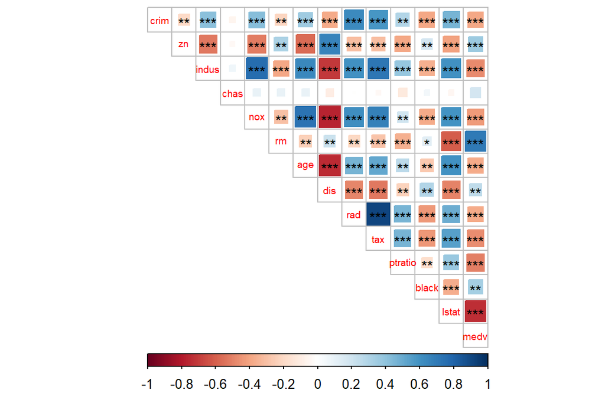

```r
# graphical overview

cor_matrix<-cor(Boston) %>% round(digits = 2)

## measuring statistical significance of correlation coefficients
testRes <- cor.mtest(cor_matrix, conf.level = 0.95)

## plotting with significant level stars
corrplot(cor_matrix, p.mat = testRes$p, method="square", type="upper", cl.pos="b", tl.pos="d", tl.cex = 0.6, sig.level = c(0.001, 0.01, 0.05), pch.cex = 0.9, insig = 'label_sig', pch.col = 'black')
```

## Preparing the data set for future analysis

### Scaling

For the purposes of lda analysis, I am first scaling the data set. As you can see, now the means of all variables are zero, so it is easy now to compare their “intensity”.

```r
# centering and standardizing variables
boston_scaled <- scale(Boston)

boston_scaled <- as.data.frame(boston_scaled)

summary(boston_scaled)
```

```
##       crim                 zn               indus              chas
##  Min.   :-0.419367   Min.   :-0.48724   Min.   :-1.5563   Min.   :-0.2723
##  1st Qu.:-0.410563   1st Qu.:-0.48724   1st Qu.:-0.8668   1st Qu.:-0.2723
##  Median :-0.390280   Median :-0.48724   Median :-0.2109   Median :-0.2723
##  Mean   : 0.000000   Mean   : 0.00000   Mean   : 0.0000   Mean   : 0.0000
##  3rd Qu.: 0.007389   3rd Qu.: 0.04872   3rd Qu.: 1.0150   3rd Qu.:-0.2723
##  Max.   : 9.924110   Max.   : 3.80047   Max.   : 2.4202   Max.   : 3.6648
##       nox                rm               age               dis
##  Min.   :-1.4644   Min.   :-3.8764   Min.   :-2.3331   Min.   :-1.2658
##  1st Qu.:-0.9121   1st Qu.:-0.5681   1st Qu.:-0.8366   1st Qu.:-0.8049
##  Median :-0.1441   Median :-0.1084   Median : 0.3171   Median :-0.2790
##  Mean   : 0.0000   Mean   : 0.0000   Mean   : 0.0000   Mean   : 0.0000
##  3rd Qu.: 0.5981   3rd Qu.: 0.4823   3rd Qu.: 0.9059   3rd Qu.: 0.6617
##  Max.   : 2.7296   Max.   : 3.5515   Max.   : 1.1164   Max.   : 3.9566
##       rad               tax             ptratio            black
##  Min.   :-0.9819   Min.   :-1.3127   Min.   :-2.7047   Min.   :-3.9033
##  1st Qu.:-0.6373   1st Qu.:-0.7668   1st Qu.:-0.4876   1st Qu.: 0.2049
##  Median :-0.5225   Median :-0.4642   Median : 0.2746   Median : 0.3808
##  Mean   : 0.0000   Mean   : 0.0000   Mean   : 0.0000   Mean   : 0.0000
##  3rd Qu.: 1.6596   3rd Qu.: 1.5294   3rd Qu.: 0.8058   3rd Qu.: 0.4332
##  Max.   : 1.6596   Max.   : 1.7964   Max.   : 1.6372   Max.   : 0.4406
##      lstat              medv
##  Min.   :-1.5296   Min.   :-1.9063
##  1st Qu.:-0.7986   1st Qu.:-0.5989
##  Median :-0.1811   Median :-0.1449
##  Mean   : 0.0000   Mean   : 0.0000
##  3rd Qu.: 0.6024   3rd Qu.: 0.2683
##  Max.   : 3.5453   Max.   : 2.9865
```

### Creating crime rate target variable

In order conduct lda analysis with crime rate as a target variable, I will need to transform it to a categorical data. I am going to create categories based on quantiles, but as the summary of this variable has indicated earlier, I am expecting to see a significant break in the third quantile.

```r
# creating a quantile vector
bins <- quantile(boston_scaled$crim)

# creating a categorical variable 'crime'
values <- c("low", "med_low", "med_high", "high")
crime <- cut(boston_scaled$crim, breaks = bins, label = values, include.lowest = TRUE)

# removing original crim from the dataset
boston_scaled <- dplyr::select(boston_scaled, -crim)

# adding the new categorical value to scaled data
boston_scaled <- data.frame(boston_scaled, crime)

summary(boston_scaled$crime)
```

```
##      low  med_low med_high     high
##      127      126      126      127
```

### Dividing to train and test sets

Finally, I am dividing the set, allocating 80% as train data, and the rest as test data.

```r
# number of rows in the Boston data set
n <- nrow(boston_scaled)

# selecting randomly 80% of the rows
ind <- sample(n,  size = n * 0.8)

# train set
train <- boston_scaled[ind,]

# test set
test <- boston_scaled[-ind,]

# saving the correct classes from test data
correct_classes <- test$crime

# removing the crime variable from test data
test <- dplyr::select(test, -crime)
```

## LDA analysis

### Fitting the model

Now the data set is ready to be fitted to LDA with crime rate as the target variable. The result is visualized with a biplot. It is clear from the plot that my initial hypothesis was correct, the cases are divided in two distinct clusters: a bigger one, consisting of all low and med_low cases, majority of med_high and a smaller one with majority of high cases and several med_high. Arrows make it clear that the strongest factor dividing the clusters seems to be accessibility of radial highways, `rad`.

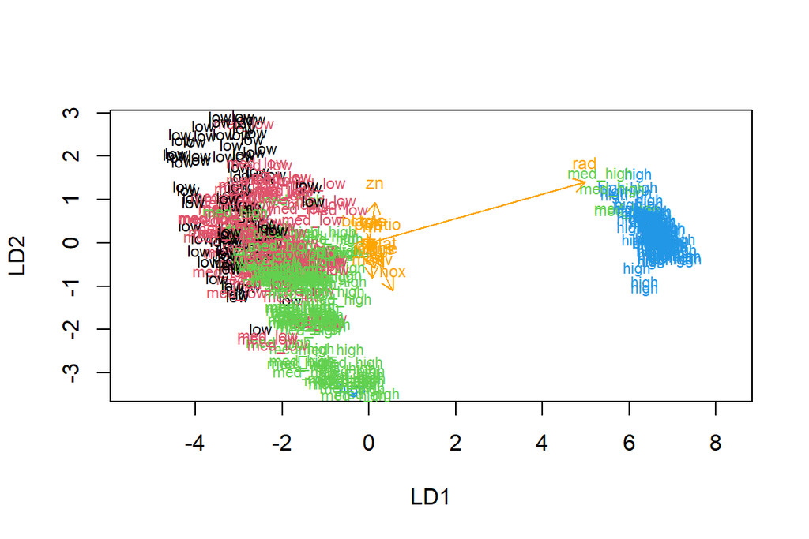

```r
lda.fit <- lda(crime ~ ., data = train)

# the function for lda biplot arrows
lda.arrows <- function(x, myscale = 1, arrow_heads = 0.1, color = "orange", tex = 0.75, choices = c(1,2)){
  heads <- coef(x)
  arrows(x0 = 0, y0 = 0,
         x1 = myscale * heads[,choices[1]],
         y1 = myscale * heads[,choices[2]], col=color, length = arrow_heads)
  text(myscale * heads[,choices], labels = row.names(heads),
       cex = tex, col=color, pos=3)
}

# target classes as numeric
classes <- as.numeric(train$crime)

# plotting the lda results
plot(lda.fit, dimen = 2, col = classes, pch = classes)
lda.arrows(lda.fit, myscale = 1.5)
```

### Testing the model

```r
lda.pred <- predict(lda.fit, newdata = test)

table(correct = correct_classes, predicted = lda.pred$class)
```

```
##           predicted
## correct    low med_low med_high high
##   low       18      12        1    0
##   med_low    2      16        6    0
##   med_high   1       9        9    2
##   high       0       0        0   26
```